# Incident analysis based on MITRE standards

Humbert Costas

11/06/2021

# Introducción

Como miembro del equipo de cybersecurity y experto en data science, se solicita tu colaboración para el análisis de un conjunto de incidentes de seguridad añadiendo información de contexto, que pueda ayudar a entender que sucedió y como mejorar.

## Objetivo

El objetivo consiste en responder las siguientes preguntas:

1. ¿Qué estandar/es podría/n añadir contexto a los incidentes?
2. ¿Cuantos incidentes estan relacionados con phishing?
3. ¿Quien estaba detras de los ataques?
4. ¿Cual fue el objetivo?
5. ¿Cómo realizaron los ataques?
6. ¿Cómo podemos protegernos?
7. ¿Qué podemos hacer para prevenir futuros ataques?
8. ¿Sería posible predecir ataques?

## Alcance

Cada pregunta tiene una puntuación máxima de 2 puntos; donde se evalua la parte análitica (1 punto) y la parte de programación (1 punto).

Es posible hacer la práctica por parejas; en tal caso, los puntos totales se dividen entre los dos alumnos, consiguiendo un máximo de 8 puntos.

# Data sets

```r
suppressPackageStartupMessages(library("dplyr"))
library("tidyr")
suppressPackageStartupMessages(library("DataExplorer"))
library("ggridges")
library("ggplot2")
suppressPackageStartupMessages(library("hrbrthemes"))
suppressPackageStartupMessages(library("viridis"))
```

## Incidents

Load incidents data set and unnest ATT&CK column.

```r
raw_incidents <- readRDS(file = "data/incidents.rds")
incidents <- raw_incidents %>% unnest(mitre_attack)
summary(incidents)
```

```
##  first_event_ts                first_alert_ts
##  Min.   :2019-01-09 13:06:03   Min.   :2019-01-09 13:06:03
##  1st Qu.:2019-05-02 14:55:04   1st Qu.:2019-05-02 14:55:04
##  Median :2019-06-03 12:27:03   Median :2019-06-03 12:28:01
##  Mean   :2019-06-11 06:34:29   Mean   :2019-06-11 07:13:06
##  3rd Qu.:2019-07-16 12:22:05   3rd Qu.:2019-07-16 12:24:02
##  Max.   :2019-09-30 20:44:00   Max.   :2019-09-30 20:44:01
##  containment_ts                    org               tactic
##  Min.   :2019-04-01 12:19:24   Length:1941        Length:1941
##  1st Qu.:2019-05-06 16:38:17   Class :character   Class :character
##  Median :2019-06-03 13:38:11   Mode  :character   Mode  :character
##  Mean   :2019-06-13 02:54:36
##  3rd Qu.:2019-07-20 21:00:50
##  Max.   :2019-09-30 21:13:48
##   technique              id              industry
##  Length:1941        Length:1941        Length:1941
##  Class :character   Class :character   Class :character
##  Mode  :character   Mode  :character   Mode  :character
##
##
##
```

Analyze character columns to identify unique values.

```r
apply(incidents, 2, function(x) length(unique(x)))
```

```
## first_event_ts first_alert_ts containment_ts            org         tactic
##            376            378            381            167              9
##      technique             id       industry
##             28             28             19
```

Set character columns as factor.

```r
incidents <- incidents %>%
  mutate_if(is.character, as.factor)
summary(incidents)
```

```
##  first_event_ts                first_alert_ts
##  Min.   :2019-01-09 13:06:03   Min.   :2019-01-09 13:06:03
##  1st Qu.:2019-05-02 14:55:04   1st Qu.:2019-05-02 14:55:04
##  Median :2019-06-03 12:27:03   Median :2019-06-03 12:28:01
##  Mean   :2019-06-11 06:34:29   Mean   :2019-06-11 07:13:06
##  3rd Qu.:2019-07-16 12:22:05   3rd Qu.:2019-07-16 12:24:02
##  Max.   :2019-09-30 20:44:00   Max.   :2019-09-30 20:44:01
##
##  containment_ts                      org                   tactic
##  Min.   :2019-04-01 12:19:24   8cea5e51: 181   Execution      :1078
##  1st Qu.:2019-05-06 16:38:17   7b18b611: 178   Initial Access : 402
##  Median :2019-06-03 13:38:11   09deb14b: 124   Impact         : 160
##  Mean   :2019-06-13 02:54:36   fb0ad6ea: 116   Defense Evasion: 157
##  3rd Qu.:2019-07-20 21:00:50   2ac86da3:  97   Persistence    :  69
##  Max.   :2019-09-30 21:13:48   10cc3cd8:  84   Collection     :  28
##                                (Other) :1161   (Other)        :  47
##                 technique         id               industry
##  Third-Party Software:490   T1072  :490   Retail       :289
##  Valid Accounts      :309   T1078  :309   Professional :272
##  PowerShell          :268   T1086  :268   Manufacturing:237
##  Resource Hijacking  :160   T1496  :160   Construction :203
##  User Execution      :136   T1204  :136   Information  :147
##  Scripting           :121   T1064  :121   Educational  :146
##  (Other)             :457   (Other):457   (Other)      :647
```

```
## 6 features with more than 20 categories ignored!
## first_event_ts: 376 categories
## first_alert_ts: 378 categories
## containment_ts: 381 categories
## org: 167 categories
## technique: 28 categories
## id: 28 categories
```

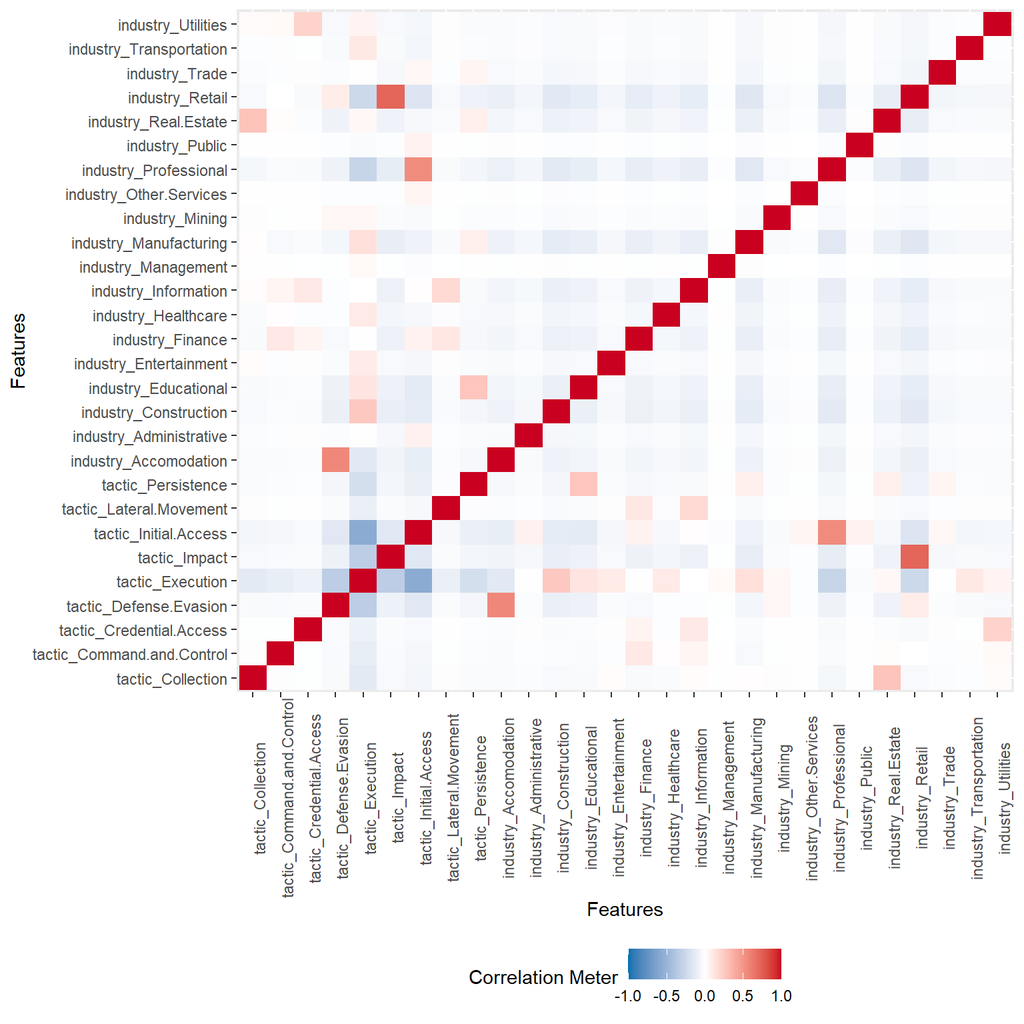

```r
plot_correlation(incidents)
```

Seems that Tactic and Industry values are interesting. Let’s see industry distribution along time.

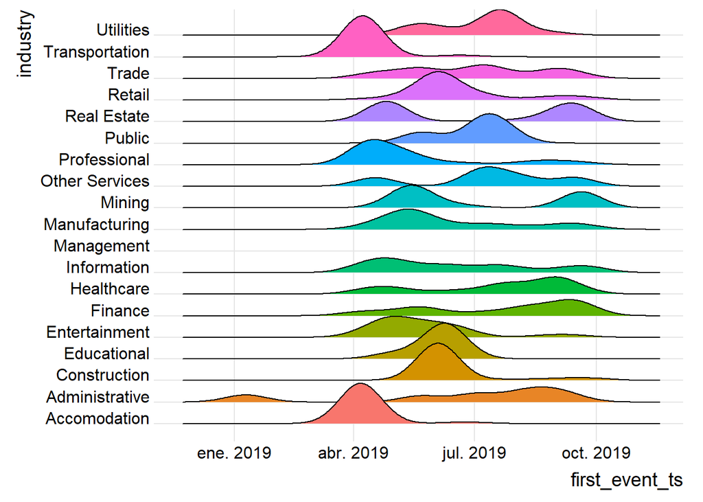

```r
# Ref: https://www.r-graph-gallery.com/294-basic-ridgeline-plot.html

ggplot(incidents, aes(x = first_event_ts, y = industry, fill = industry)) +
  geom_density_ridges() +
  theme_ridges() +
  theme(legend.position = "none")
```

The time series distribution is based on first event. We can calculate the duration of the incidents using containment time.

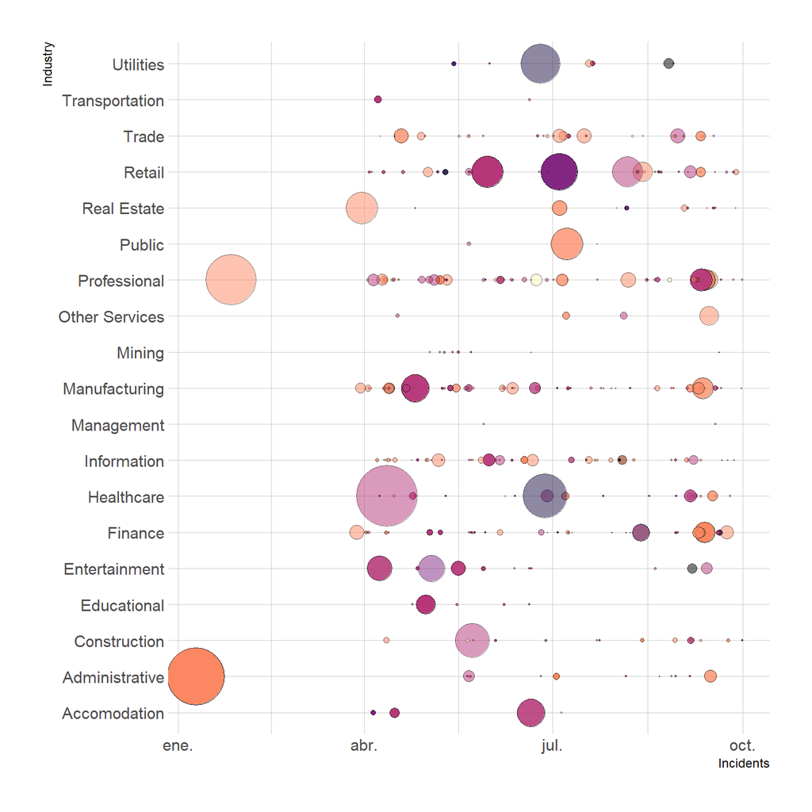

```r
# Ref: https://www.r-graph-gallery.com/320-the-basis-of-bubble-plot.html
incidents <- incidents %>% mutate(duration = round(as.numeric(containment_ts - first_event_ts)/3600, 2))

incidents %>%
  arrange(desc(first_event_ts)) %>%
  # mutate(country = factor(country, country)) %>%
  ggplot(aes(x=first_event_ts, y=industry, size=duration, fill=tactic)) +
  geom_point(alpha=0.5, shape=21, color="black") +
  scale_size(range = c(.1, 20), name="Duration") +
    scale_fill_viridis(discrete=TRUE, guide=FALSE, option="A") +
    theme_ipsum() +
    theme(legend.position="bottom") +
    ylab("Industry") +
    xlab("Incidents") +
    theme(legend.position = "none")
```

## CWE

```r
source("data-raw/mitre-cwe.R")
raw_cwes <- bind_rows(cwe.weaknesses, cwe.categories, cwe.views)
rm(cwe.weaknesses, cwe.categories, cwe.views)
dim(raw_cwes)
```

```
## [1] 1338   24
```

## CVE

```r
#source("data-raw/nist-cve.R")
# raw_cves <- ""
```

## ATT&CK

```r
source("data-raw/mitre-attck.R")
```

## SHIELD

```r
# source("data-raw/mitre-shield.R")
```

## CPE

```r
# source("data-raw/nist-cpe.R")
```

## CAPEC

```r
# source("data-raw/mitre-capec.R")
```

## CAR

```r
# source("data-raw/mitre-car.R")
```

# Data Model

[figure not shown]

CyberSecurity Standards

# Análisis

## ¿Qué estandar/es podría/n añadir contexto a los incidentes?

Mitre Att&ck. En él encontramos una gran base de conocimiento de las principales **tácticas** y **técnicas** usadas por los atacantes en base a datos reales. Mediante esta información, podremos ampliar el conocimiento obtenido en el *dataset* original de incidentes. Otro valor añadido interesante que nos puede aportar este estándar son datos sobre los **grupos de ciber atacantes** que pueden estar detrás de nuestros incidentes y la consciencia de **cómo podemos resolver las vulnerabilidades** que estos atacantes han aprovechado para explotarlas.

En este apartado, usaremos el lenguaje R para obtener un conjunto de tablas con información útil pero específica. Usaremos cada una de ellas para resolver las distintas cuestiones planteadas.

Interpretando que las líneas repetidas son registros duplicados de un mismo incidente (ya que coinciden en tipo de incidente, fecha, duración y organización), inicialmente, crearemos una tabla en la que eliminaremos las líneas repetidas y ordenaremos los incidentes resultantes de máxima a mínima duración (para poder visualizar fácilmente los incidentes más largos cuando echemos un vistazo visual a la tabla).

```r
nrow(incidents)
```

```
## [1] 1941
```

```r
duration_table <- distinct(incidents) %>% arrange(desc(duration))
nrow(duration_table)
```

```
## [1] 489
```

Una vez tenemos los incidentes limpios de registros repetidos, procederemos a obtener una tabla con cada tipo de información que creemos van a aportar conocimiento útil en los puntos posteriores.

Ayudándonos de las tablas de *Mitre Att&ck*, ya tenemos la estructura necesaria para ampliar la información de **tácticas** y **técnicas** en sendas tablas (haremos *left join* con *attck.tactics* y *attck.techniques* para que a las filas de *duration_table* se les incorporen las columnas de la técnica o táctica que le corresponda). No obstante, para extender la información sobre posibles **grupos** atacantes (mediante la tabla *attck.groups*) y sobre las **mitigaciones** de las vulnerabilidades usadas por los atacantes (mediante la tabla *attck.mitigations*) de necesitamos ayudarnos de una tabla de relaciones (*attck.relations*) mediante la que podremos, entonces, fusionar la información de los incidentes con la de los grupos y mitigaciones.

1. Información sobre las **tácticas** empeladas en cada incidente.

```r
tactics <- left_join(duration_table, attck.tactics, by = c("tactic" = "name"))
nrow(tactics)
```

```
## [1] 489
```

```r
head (select(tactics, tactic, external_id, url, description), n = 10L)
```

```
## # A tibble: 10 x 4
##    tactic      external_id url                description
##    <chr>       <chr>       <chr>              <chr>
##  1 Execution   TA0002      https://attack.mi~ "The adversary is trying to run m~
##  2 Initial Ac~ TA0001      https://attack.mi~ "The adversary is trying to get i~
##  3 Initial Ac~ TA0001      https://attack.mi~ "The adversary is trying to get i~
##  4 Command an~ TA0011      https://attack.mi~ "The adversary is trying to commu~
##  5 Command an~ TA0011      https://attack.mi~ "The adversary is trying to commu~
##  6 Defense Ev~ TA0005      https://attack.mi~ "The adversary is trying to avoid~
##  7 Defense Ev~ TA0005      https://attack.mi~ "The adversary is trying to avoid~
##  8 Execution   TA0002      https://attack.mi~ "The adversary is trying to run m~
##  9 Initial Ac~ TA0001      https://attack.mi~ "The adversary is trying to get i~
## 10 Initial Ac~ TA0001      https://attack.mi~ "The adversary is trying to get i~
```

```r
techniques <- left_join(duration_table, attck.techniques, by = c("technique" = "name"))
nrow(techniques)
```

```
## [1] 544
```

```r
head (select(techniques, technique, external_id, url, description), n = 10L)
```

```
## # A tibble: 10 x 4
##    technique     external_id url                description
##    <chr>         <chr>       <chr>              <chr>
##  1 Service Exec~ T1569.002   https://attack.mi~ "Adversaries may abuse the Wind~
##  2 Valid Accoun~ T1078       https://attack.mi~ "Adversaries may obtain and abu~
##  3 Valid Accoun~ T1078       https://attack.mi~ "Adversaries may obtain and abu~
##  4 Remote Acces~ <NA>        <NA>                <NA>
##  5 Remote Acces~ <NA>        <NA>                <NA>
##  6 Masquerading  T1036       https://attack.mi~ "Adversaries may attempt to man~
##  7 Masquerading  T1036       https://attack.mi~ "Adversaries may attempt to man~
##  8 User Executi~ T1204       https://attack.mi~ "An adversary may rely upon spe~
##  9 Spearphishin~ T1566.002   https://attack.mi~ "Adversaries may send spearphis~
## 10 Spearphishin~ T1598.003   https://attack.mi~ "Adversaries may send spearphis~
```

Comprobamos que en la tabla *techniques* hay más filas que en la *tabla duration_table*. Eso es debido a que hay algunas técnicas (como, por ejemplo *Spearphishing Link*) que tienen más de una subtécnicas y, con esta fusión, obtenemos un registro para cada posible subtécnica empleadas en nuestros incidentes. Podemos comprobarlo a continuación ya que mostraremos los diez primeros registros de las tablas *duration_table* y *techniques*. Si nos fijamos en la fila 10 de la tabla *techniques*, vemos que es otra alternativa de subtécnica al incidente también representado en la fila anterior (lo podemos verificar fijándonos en las columnas *org* y *first_event_ts*).

```r
head (select(duration_table, technique, org, first_event_ts), n = 10L)
```

```
## # A tibble: 10 x 3
##    technique           org      first_event_ts
##    <fct>               <fct>    <dttm>
##  1 Service Execution   27d56d69 2019-04-12 02:39:39
##  2 Valid Accounts      bf1e56e4 2019-01-09 13:06:03
##  3 Valid Accounts      b56e9237 2019-01-26 13:11:04
##  4 Remote Access Tools 03ae7598 2019-06-27 11:33:04
##  5 Remote Access Tools 7a3d640b 2019-06-25 02:43:03
##  6 Masquerading        b52887d2 2019-07-04 10:04:03
##  7 Masquerading        b52887d2 2019-07-04 10:04:03
##  8 User Execution      17a84413 2019-05-23 07:22:02
##  9 Spearphishing Link  4cefe35f 2019-07-08 00:00:00
## 10 Valid Accounts      cb9047bd 2019-03-30 17:26:01
```

```r
head (select(techniques, technique, external_id, org, first_event_ts), n = 10L)
```

```
## # A tibble: 10 x 4
##    technique           external_id org      first_event_ts
##    <chr>               <chr>       <fct>    <dttm>
##  1 Service Execution   T1569.002   27d56d69 2019-04-12 02:39:39
##  2 Valid Accounts      T1078       bf1e56e4 2019-01-09 13:06:03
##  3 Valid Accounts      T1078       b56e9237 2019-01-26 13:11:04
##  4 Remote Access Tools <NA>        03ae7598 2019-06-27 11:33:04
##  5 Remote Access Tools <NA>        7a3d640b 2019-06-25 02:43:03
##  6 Masquerading        T1036       b52887d2 2019-07-04 10:04:03
##  7 Masquerading        T1036       b52887d2 2019-07-04 10:04:03
##  8 User Execution      T1204       17a84413 2019-05-23 07:22:02
##  9 Spearphishing Link  T1566.002   4cefe35f 2019-07-08 00:00:00
## 10 Spearphishing Link  T1598.003   4cefe35f 2019-07-08 00:00:00
```

3. Si queremos información de las **mitigaciones / grupos** debemos obtener las relaciones de la tabla *techniques* creada anteriormente. Para ello, con una *inner join* obtendremos la fusión de las técnicas empleadas en nuestros incidentes y de todas las relaciones existentes con estas técnicas de la tabla de relaciones *attck.relations* (pero descartando cualquier fila de ambas tablas que no coincida con la condición de la *join* porque no queremos filas sin relación alguna).

```r
joined_data <- inner_join(attck.relations %>% select(from, to), techniques, by = c("to"= "id.x"))
```

4. Para obtener las **mitigaciones** de las técnicas usadas en los incidentes recopilados, del resultado de la anterior *inner join* filtraremos sólo aquellas filas donde la columna que nos indica que tipo de relación es tenga la letra *M* que indica que es del tipo mitigación.

```r
mitigations <- joined_data[grep("M", joined_data$from), ] %>% arrange(desc(first_event_ts))
head (select(mitigations, from, to, first_event_ts, org, technique), n = 10L)
```

```
##     from    to      first_event_ts      org            technique
## 1  M1017 T1072 2019-09-30 19:44:05 407f2095 Third-Party Software
## 2  M1051 T1072 2019-09-30 19:44:05 407f2095 Third-Party Software
## 3  M1029 T1072 2019-09-30 19:44:05 407f2095 Third-Party Software
## 4  M1030 T1072 2019-09-30 19:44:05 407f2095 Third-Party Software
## 5  M1027 T1072 2019-09-30 19:44:05 407f2095 Third-Party Software
## 6  M1026 T1072 2019-09-30 19:44:05 407f2095 Third-Party Software
## 7  M1032 T1072 2019-09-30 19:44:05 407f2095 Third-Party Software
## 8  M1015 T1072 2019-09-30 19:44:05 407f2095 Third-Party Software
## 9  M1018 T1072 2019-09-30 19:44:05 407f2095 Third-Party Software
## 10 M1017 T1072 2019-09-30 09:23:17 10cc3cd8 Third-Party Software
```

Para terminar de recopilar las columnas interesantes, nos quedará una *left join* con la tabla *attck.mitigations* para que nuestra tabla *mitigations* se complete con las columnas de la tabla *attck.mitigations*.

```r
ncol(mitigations)
```

```
## [1] 24
```

```r
mitigations <- left_join(mitigations, attck.mitigations, by = c("from" = "external_id"))
ncol(mitigations)
```

```
## [1] 35
```

5. Para obtener los **grupos** de los posibles atacantes que usan las técnicas encontradas en los incidentes recopilados, del resultado de la anterior *inner join* ahora filtraremos sólo por aquellas filas donde la columna que nos indica que tipo de relación es tenga la letra *G* que indica que es del tipo grupo.

```r
groups <- joined_data[grep("G", joined_data$from), ] %>% arrange(desc(first_event_ts))
head (select(groups, from, to, first_event_ts, org, technique), n = 10L)
```

```
##     from    to      first_event_ts      org            technique
## 1  G0050 T1072 2019-09-30 19:44:05 407f2095 Third-Party Software
## 2  G0028 T1072 2019-09-30 19:44:05 407f2095 Third-Party Software
## 3  G0091 T1072 2019-09-30 19:44:05 407f2095 Third-Party Software
## 4  G0050 T1072 2019-09-30 09:23:17 10cc3cd8 Third-Party Software
## 5  G0028 T1072 2019-09-30 09:23:17 10cc3cd8 Third-Party Software
## 6  G0091 T1072 2019-09-30 09:23:17 10cc3cd8 Third-Party Software
## 7  G0050 T1072 2019-09-27 09:22:00 50d25dff Third-Party Software
## 8  G0028 T1072 2019-09-27 09:22:00 50d25dff Third-Party Software
## 9  G0091 T1072 2019-09-27 09:22:00 50d25dff Third-Party Software
## 10 G0050 T1072 2019-09-26 18:54:02 6041707a Third-Party Software
```

Para terminar de recopilar las columnas interesantes, nos quedará una *left join* con la tabla *attck.groups* para que nuestra tabla *groups* se complete con las columnas de la tabla *attck.groups*.

```r
ncol(groups)
```

```
## [1] 24
```

```r
groups <- left_join(groups, attck.groups, by = c("from" = "external_id"))
ncol(groups)
```

```
## [1] 34
```

En este momento, se han creado un conjunto de tablas para resolver las distintas cuestiones: * duration_table * tactics * techniques * groups * mitigations

## ¿Cuantos incidentes estan relacionados con phishing?

Anteriormente, se ha constatado que la técnica *Spearphishing Link* tenía distintas subtécnicas. Con esto, se introduce la idea que para saber si un incidente está relacionado con *phishing* puede ser una buena idea buscar entre las técnicas. La decisión tomada es la de buscar el texto *phishing* en cada uno de los registros de la columna *technique* de la tabla *duration_table* con todos los incidentes recogidos.

```r
phishing <- duration_table[grep("phishing", duration_table$technique), ]
nrow(phishing)
```

```
## [1] 55
```

```r
count(distinct(phishing, first_event_ts, org))
```

```
## # A tibble: 1 x 1
##       n
##   <int>
## 1    55
```

```r
library(knitr)
kable(phishing, caption = "Incidentes relacionados con técnicas de *Phishing*")
```

Incidentes relacionados con técnicas de *Phishing*

| first_event_ts | first_alert_ts | containment_ts | org | tactic | technique | id | industry | duration |
| --- | --- | --- | --- | --- | --- | --- | --- | --- |
| 2019-07-08 00:00:00 | 2019-07-08 00:00:00 | 2019-08-03 03:19:18 | 4cefe35f | Initial Access | Spearphishing Link | T1192 | Public | 627.32 |
| 2019-08-13 17:43:03 | 2019-08-13 17:44:00 | 2019-08-23 03:19:33 | 9516d73d | Initial Access | Spearphishing Link | T1192 | Retail | 225.61 |
| 2019-03-28 14:01:01 | 2019-03-28 14:01:01 | 2019-04-02 10:10:42 | 1abcf80b | Initial Access | Spearphishing Link | T1192 | Finance | 116.16 |
| 2019-07-16 12:22:05 | 2019-07-16 12:24:02 | 2019-07-21 05:50:24 | 73cd3dc5 | Initial Access | Spearphishing Link | T1192 | Trade | 113.47 |
| 2019-09-23 13:15:04 | 2019-09-23 13:16:02 | 2019-09-27 18:16:44 | 2a87c494 | Initial Access | Spearphishing Link | T1192 | Finance | 101.03 |
| 2019-05-06 19:59:04 | 2019-05-06 19:57:46 | 2019-05-10 16:31:45 | b041a104 | Initial Access | Spearphishing Link | T1192 | Information | 92.54 |
| 2019-06-11 18:03:57 | 2019-06-11 18:03:57 | 2019-06-14 21:03:42 | ac33b693 | Initial Access | Spearphishing Link | T1192 | Manufacturing | 75.00 |
| 2019-04-09 18:10:02 | 2019-04-09 18:11:00 | 2019-04-12 11:44:00 | bed58001 | Initial Access | Spearphishing Link | T1192 | Professional | 65.57 |
| 2019-05-10 21:18:02 | 2019-05-10 21:19:01 | 2019-05-13 13:49:15 | 3be8d3c9 | Initial Access | Spearphishing Link | T1192 | Professional | 64.52 |
| 2019-03-30 07:59:55 | 2019-03-30 07:59:55 | 2019-04-01 12:19:24 | ac33b693 | Initial Access | Spearphishing Link | T1192 | Manufacturing | 52.32 |
| 2019-05-01 17:31:00 | 2019-05-01 17:31:00 | 2019-05-03 20:49:08 | b52887d2 | Initial Access | Spearphishing Link | T1192 | Retail | 51.30 |
| 2019-04-10 15:28:03 | 2019-04-10 15:29:00 | 2019-04-11 21:20:43 | 074a904e | Initial Access | Spearphishing Link | T1192 | Professional | 29.88 |
| 2019-07-10 18:39:03 | 2019-07-10 18:40:01 | 2019-07-11 17:52:41 | 8cea5e51 | Initial Access | Spearphishing Link | T1192 | Retail | 23.23 |
| 2019-04-02 19:25:02 | 2019-04-02 19:25:02 | 2019-04-03 16:23:41 | 6589fb64 | Initial Access | Spearphishing Link | T1192 | Manufacturing | 20.98 |
| 2019-06-06 16:05:07 | 2019-06-06 16:05:07 | 2019-06-07 11:28:23 | db348605 | Initial Access | Spearphishing Link | T1192 | Manufacturing | 19.39 |
| 2019-07-02 18:47:03 | 2019-07-02 18:48:00 | 2019-07-03 13:58:32 | 43b014bf | Initial Access | Spearphishing Link | T1192 | Administrative | 19.19 |
| 2019-06-05 20:36:00 | 2019-06-05 20:36:00 | 2019-06-06 12:15:22 | fa2f04f0 | Initial Access | Spearphishing Link | T1192 | Finance | 15.66 |
| 2019-04-11 19:49:00 | 2019-04-11 19:50:00 | 2019-04-12 10:53:25 | 7b18b611 | Initial Access | Spearphishing Link | T1192 | Construction | 15.07 |
| 2019-09-27 18:13:02 | 2019-09-27 18:14:05 | 2019-09-28 08:52:37 | 9516d73d | Initial Access | Spearphishing Link | T1192 | Retail | 14.66 |
| 2019-08-20 17:31:02 | 2019-08-20 17:31:03 | 2019-08-21 07:33:49 | 0cf83eaa | Initial Access | Spearphishing Link | T1192 | Manufacturing | 14.05 |
| 2019-09-19 19:45:05 | 2019-09-19 19:46:00 | 2019-09-20 09:17:15 | d282ca2e | Initial Access | Spearphishing Link | T1192 | Finance | 13.54 |
| 2019-08-29 10:18:05 | 2019-08-29 10:18:05 | 2019-08-29 20:00:07 | 17a84413 | Initial Access | Spearphishing Link | T1192 | Construction | 9.70 |
| 2019-09-06 15:39:00 | 2019-09-06 15:41:01 | 2019-09-07 01:14:13 | 3c8cab02 | Initial Access | Spearphishing Link | T1192 | Construction | 9.59 |
| 2019-04-15 23:14:59 | 2019-04-15 23:15:37 | 2019-04-16 08:37:30 | 6b527356 | Initial Access | Spearphishing Link | T1192 | Information | 9.38 |
| 2019-04-11 02:32:03 | 2019-04-11 02:33:00 | 2019-04-11 11:22:55 | 8848ae62 | Initial Access | Spearphishing Link | T1192 | Professional | 8.85 |
| 2019-08-13 13:04:03 | 2019-08-13 13:04:03 | 2019-08-13 18:37:39 | 3c8cab02 | Initial Access | Spearphishing Link | T1192 | Construction | 5.56 |
| 2019-04-12 19:26:22 | 2019-04-12 19:49:02 | 2019-04-13 00:50:43 | 8922d54f | Initial Access | Spearphishing Link | T1192 | Information | 5.41 |
| 2019-05-01 09:04:04 | 2019-05-01 09:04:04 | 2019-05-01 13:51:56 | 76ebb224 | Initial Access | Spearphishing Link | T1192 | Information | 4.80 |
| 2019-05-21 10:14:00 | 2019-05-21 10:14:00 | 2019-05-21 14:45:16 | fd42c0e9 | Initial Access | Spearphishing Link | T1192 | Trade | 4.52 |
| 2019-06-03 14:07:00 | 2019-06-03 14:08:00 | 2019-06-03 18:31:57 | 6e74fcb7 | Initial Access | Spearphishing Link | T1192 | Professional | 4.42 |
| 2019-04-11 15:48:00 | 2019-04-11 15:48:00 | 2019-04-11 20:11:03 | d282ca2e | Initial Access | Spearphishing Link | T1192 | Finance | 4.38 |
| 2019-06-28 12:11:01 | 2019-06-28 12:12:00 | 2019-06-28 16:25:48 | fe25e5d9 | Initial Access | Spearphishing Link | T1192 | Trade | 4.25 |
| 2019-08-29 01:56:03 | 2019-08-29 01:56:04 | 2019-08-29 05:55:48 | 130308f2 | Initial Access | Spearphishing Link | T1192 | Trade | 4.00 |
| 2019-09-23 23:21:03 | 2019-09-23 23:22:00 | 2019-09-24 02:48:57 | 3c8cab02 | Initial Access | Spearphishing Link | T1192 | Construction | 3.46 |
| 2019-06-05 07:14:03 | 2019-06-05 07:14:03 | 2019-06-05 10:00:38 | 5aa2992c | Initial Access | Spearphishing Link | T1192 | Professional | 2.78 |
| 2019-08-14 11:52:05 | 2019-08-14 11:53:02 | 2019-08-14 14:33:24 | 01aa9757 | Initial Access | Spearphishing Link | T1192 | Retail | 2.69 |
| 2019-06-07 12:12:01 | 2019-06-07 12:13:00 | 2019-06-07 14:52:54 | 8848ae62 | Initial Access | Spearphishing Link | T1192 | Professional | 2.68 |
| 2019-04-15 07:17:20 | 2019-04-15 07:17:49 | 2019-04-15 09:30:50 | 217ac347 | Initial Access | Spearphishing Link | T1192 | Healthcare | 2.22 |
| 2019-04-01 17:22:05 | 2019-04-01 17:23:00 | 2019-04-01 19:23:33 | 1abcf80b | Initial Access | Spearphishing Link | T1192 | Finance | 2.02 |
| 2019-05-16 19:19:03 | 2019-05-16 19:18:44 | 2019-05-16 20:38:21 | 00275457 | Initial Access | Spearphishing Link | T1192 | Trade | 1.32 |
| 2019-04-11 17:28:34 | 2019-04-11 17:29:00 | 2019-04-11 18:35:33 | 8922d54f | Initial Access | Spearphishing Link | T1192 | Information | 1.12 |
| 2019-04-30 20:46:37 | 2019-04-30 20:48:00 | 2019-04-30 21:53:29 | 8922d54f | Initial Access | Spearphishing Link | T1192 | Information | 1.11 |
| 2019-06-12 13:17:00 | 2019-06-12 13:17:00 | 2019-06-12 13:56:11 | bbfab332 | Initial Access | Spearphishing Link | T1192 | Entertainment | 0.65 |
| 2019-07-09 19:30:56 | 2019-07-09 19:32:02 | 2019-07-09 20:07:55 | db348605 | Initial Access | Spearphishing Link | T1192 | Manufacturing | 0.62 |
| 2019-05-23 14:01:59 | 2019-05-23 14:01:59 | 2019-05-23 14:29:30 | 8922d54f | Initial Access | Spearphishing Link | T1192 | Information | 0.46 |
| 2019-09-05 17:34:00 | 2019-09-05 17:34:04 | 2019-09-05 17:57:49 | 3c8cab02 | Initial Access | Spearphishing Link | T1192 | Construction | 0.40 |
| 2019-08-29 20:05:03 | 2019-08-29 20:05:03 | 2019-08-29 20:22:12 | 03ae7598 | Initial Access | Spearphishing Link | T1192 | Healthcare | 0.29 |
| 2019-08-29 13:50:00 | 2019-08-29 13:50:04 | 2019-08-29 14:05:25 | 8922d54f | Initial Access | Spearphishing Link | T1192 | Information | 0.26 |
| 2019-08-28 11:56:05 | 2019-08-28 11:58:00 | 2019-08-28 12:08:02 | df9fcae4 | Initial Access | Spearphishing Link | T1192 | Manufacturing | 0.20 |
| 2019-08-29 20:38:13 | 2019-08-29 20:43:00 | 2019-08-29 20:48:53 | 03ae7598 | Initial Access | Spearphishing Link | T1192 | Healthcare | 0.18 |
| 2019-09-16 17:23:03 | 2019-09-16 17:24:02 | 2019-09-16 17:33:05 | bfb647fe | Initial Access | Spearphishing Link | T1192 | Professional | 0.17 |
| 2019-04-30 13:12:01 | 2019-04-30 13:12:01 | 2019-04-30 13:20:31 | 16258713 | Initial Access | Spearphishing Link | T1192 | Information | 0.14 |
| 2019-06-24 13:50:05 | 2019-06-24 13:50:05 | 2019-06-24 13:56:18 | db348605 | Initial Access | Spearphishing Link | T1192 | Manufacturing | 0.10 |
| 2019-04-10 16:07:00 | 2019-04-10 16:08:00 | 2019-04-10 16:10:59 | 048c18b6 | Initial Access | Spearphishing Link | T1192 | Finance | 0.07 |
| 2019-04-08 16:17:52 | 2019-04-08 16:18:29 | 2019-04-08 16:20:50 | 00275457 | Initial Access | Spearphishing Link | T1192 | Trade | 0.05 |

Para reafirmarnos de la decisión inicial de prescindir de las filas repetidas, seguiremos el mismo procedimiento con la tabla *incidents* que contiene todos los incidentes y, a posteriori, contaremos las filas descartando las repetidas. Con esto se quiere confirmar que el resultado final es el mismo.

```r
phishing_from_incident <- incidents[grep("phishing", incidents$technique), ]
nrow(phishing_from_incident)
```

```
## [1] 82
```

```r
count(distinct(phishing_from_incident, first_event_ts, org))
```

```
## # A tibble: 1 x 1
##       n
##   <int>
## 1    55
```

```r
kable(phishing_from_incident, caption = "Incidentes relacionados con técnicas de *Phishing* (método 2)")
```

Incidentes relacionados con técnicas de *Phishing* (método 2)

| first_event_ts | first_alert_ts | containment_ts | org | tactic | technique | id | industry | duration |
| --- | --- | --- | --- | --- | --- | --- | --- | --- |
| 2019-08-13 13:04:03 | 2019-08-13 13:04:03 | 2019-08-13 18:37:39 | 3c8cab02 | Initial Access | Spearphishing Link | T1192 | Construction | 5.56 |
| 2019-04-11 17:28:34 | 2019-04-11 17:29:00 | 2019-04-11 18:35:33 | 8922d54f | Initial Access | Spearphishing Link | T1192 | Information | 1.12 |
| 2019-07-09 19:30:56 | 2019-07-09 19:32:02 | 2019-07-09 20:07:55 | db348605 | Initial Access | Spearphishing Link | T1192 | Manufacturing | 0.62 |
| 2019-05-23 14:01:59 | 2019-05-23 14:01:59 | 2019-05-23 14:29:30 | 8922d54f | Initial Access | Spearphishing Link | T1192 | Information | 0.46 |
| 2019-04-01 17:22:05 | 2019-04-01 17:23:00 | 2019-04-01 19:23:33 | 1abcf80b | Initial Access | Spearphishing Link | T1192 | Finance | 2.02 |
| 2019-06-05 07:14:03 | 2019-06-05 07:14:03 | 2019-06-05 10:00:38 | 5aa2992c | Initial Access | Spearphishing Link | T1192 | Professional | 2.78 |
| 2019-06-12 13:17:00 | 2019-06-12 13:17:00 | 2019-06-12 13:56:11 | bbfab332 | Initial Access | Spearphishing Link | T1192 | Entertainment | 0.65 |
| 2019-04-15 23:14:59 | 2019-04-15 23:15:37 | 2019-04-16 08:37:30 | 6b527356 | Initial Access | Spearphishing Link | T1192 | Information | 9.38 |
| 2019-09-23 23:21:03 | 2019-09-23 23:22:00 | 2019-09-24 02:48:57 | 3c8cab02 | Initial Access | Spearphishing Link | T1192 | Construction | 3.46 |
| 2019-04-11 02:32:03 | 2019-04-11 02:33:00 | 2019-04-11 11:22:55 | 8848ae62 | Initial Access | Spearphishing Link | T1192 | Professional | 8.85 |
| 2019-04-11 02:32:03 | 2019-04-11 02:33:00 | 2019-04-11 11:22:55 | 8848ae62 | Initial Access | Spearphishing Link | T1192 | Professional | 8.85 |
| 2019-06-03 14:07:00 | 2019-06-03 14:08:00 | 2019-06-03 18:31:57 | 6e74fcb7 | Initial Access | Spearphishing Link | T1192 | Professional | 4.42 |
| 2019-06-28 12:11:01 | 2019-06-28 12:12:00 | 2019-06-28 16:25:48 | fe25e5d9 | Initial Access | Spearphishing Link | T1192 | Trade | 4.25 |
| 2019-04-11 02:32:03 | 2019-04-11 02:33:00 | 2019-04-11 11:22:55 | 8848ae62 | Initial Access | Spearphishing Link | T1192 | Professional | 8.85 |
| 2019-04-11 02:32:03 | 2019-04-11 02:33:00 | 2019-04-11 11:22:55 | 8848ae62 | Initial Access | Spearphishing Link | T1192 | Professional | 8.85 |
| 2019-03-30 07:59:55 | 2019-03-30 07:59:55 | 2019-04-01 12:19:24 | ac33b693 | Initial Access | Spearphishing Link | T1192 | Manufacturing | 52.32 |
| 2019-07-10 18:39:03 | 2019-07-10 18:40:01 | 2019-07-11 17:52:41 | 8cea5e51 | Initial Access | Spearphishing Link | T1192 | Retail | 23.23 |
| 2019-07-02 18:47:03 | 2019-07-02 18:48:00 | 2019-07-03 13:58:32 | 43b014bf | Initial Access | Spearphishing Link | T1192 | Administrative | 19.19 |
| 2019-07-02 18:47:03 | 2019-07-02 18:48:00 | 2019-07-03 13:58:32 | 43b014bf | Initial Access | Spearphishing Link | T1192 | Administrative | 19.19 |
| 2019-07-02 18:47:03 | 2019-07-02 18:48:00 | 2019-07-03 13:58:32 | 43b014bf | Initial Access | Spearphishing Link | T1192 | Administrative | 19.19 |
| 2019-07-02 18:47:03 | 2019-07-02 18:48:00 | 2019-07-03 13:58:32 | 43b014bf | Initial Access | Spearphishing Link | T1192 | Administrative | 19.19 |
| 2019-07-02 18:47:03 | 2019-07-02 18:48:00 | 2019-07-03 13:58:32 | 43b014bf | Initial Access | Spearphishing Link | T1192 | Administrative | 19.19 |
| 2019-07-02 18:47:03 | 2019-07-02 18:48:00 | 2019-07-03 13:58:32 | 43b014bf | Initial Access | Spearphishing Link | T1192 | Administrative | 19.19 |
| 2019-07-02 18:47:03 | 2019-07-02 18:48:00 | 2019-07-03 13:58:32 | 43b014bf | Initial Access | Spearphishing Link | T1192 | Administrative | 19.19 |
| 2019-09-19 19:45:05 | 2019-09-19 19:46:00 | 2019-09-20 09:17:15 | d282ca2e | Initial Access | Spearphishing Link | T1192 | Finance | 13.54 |
| 2019-09-19 19:45:05 | 2019-09-19 19:46:00 | 2019-09-20 09:17:15 | d282ca2e | Initial Access | Spearphishing Link | T1192 | Finance | 13.54 |
| 2019-09-19 19:45:05 | 2019-09-19 19:46:00 | 2019-09-20 09:17:15 | d282ca2e | Initial Access | Spearphishing Link | T1192 | Finance | 13.54 |
| 2019-09-19 19:45:05 | 2019-09-19 19:46:00 | 2019-09-20 09:17:15 | d282ca2e | Initial Access | Spearphishing Link | T1192 | Finance | 13.54 |
| 2019-09-19 19:45:05 | 2019-09-19 19:46:00 | 2019-09-20 09:17:15 | d282ca2e | Initial Access | Spearphishing Link | T1192 | Finance | 13.54 |
| 2019-03-28 14:01:01 | 2019-03-28 14:01:01 | 2019-04-02 10:10:42 | 1abcf80b | Initial Access | Spearphishing Link | T1192 | Finance | 116.16 |

[output cut: 52 more lines]

Para obtener que técnicas de pshishing se ha utilizado, obtendremos los distintos valores de la tabla *techniques*.

```r
distinct(phishing, technique)
```

```
## # A tibble: 1 x 1
##   technique
##   <fct>
## 1 Spearphishing Link
```

Hemos encontrado **55 incidentes con la técnica Spearphishing Link**. Además, Hemos comprobado cómo hay **55 registros y los 55 hacen referencia a diferentes incidentes**.

A modo de resumen, crearemos una tabla en la que contabilizamos, por industria, el número de incidentes de phishing detectados y su duración media:

```r
phishing_summary <- (phishing %>% group_by(industry) %>% summarise(n = n()))
phishing_summary <- left_join(phishing_summary, phishing %>% group_by(industry) %>% summarise_at(vars(duration), funs(mean(., na.rm=TRUE))), by = c("industry" = "industry"))
kable(phishing_summary, caption = "Resumen: indicentes por industria / duración media")
```

Resumen: indicentes por industria / duración media

| industry | n | duration |
| --- | --- | --- |
| Administrative | 1 | 19.1900000 |
| Construction | 6 | 7.2966667 |
| Entertainment | 1 | 0.6500000 |
| Finance | 7 | 36.1228571 |
| Healthcare | 3 | 0.8966667 |
| Information | 9 | 12.8022222 |
| Manufacturing | 8 | 22.8325000 |
| Professional | 8 | 22.3587500 |
| Public | 1 | 627.3200000 |
| Retail | 5 | 63.4980000 |
| Trade | 6 | 21.2683333 |

Visualizaremos estos resultados en dos gráficos:

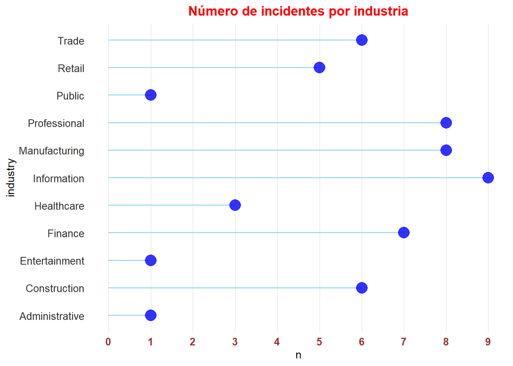

```r
ggplot(phishing_summary, aes(x=industry, y=n)) +
      geom_segment( aes(x=industry, xend=industry, y=0, yend=n), color="skyblue") +
      geom_point(color="blue", size=5, alpha=0.8) +
      theme_light() +
      coord_flip() +
      scale_y_continuous(breaks=seq(0,max(phishing_summary$n),1)) +
      theme(
          panel.grid.major.y = element_blank(),
          panel.grid.minor = element_blank(),
          panel.border = element_blank(),
          axis.ticks.y = element_blank(),
          axis.ticks.x = element_blank(),
          axis.text.y = element_text(color="#333333", size=10),
          axis.text.x = element_text(face="bold", color="#993333", size=10)
      ) + ggtitle ("Número de incidentes por industria") +
      theme (plot.title = element_text(hjust=0.5, face="bold", color="red", lineheight=1.5))
```

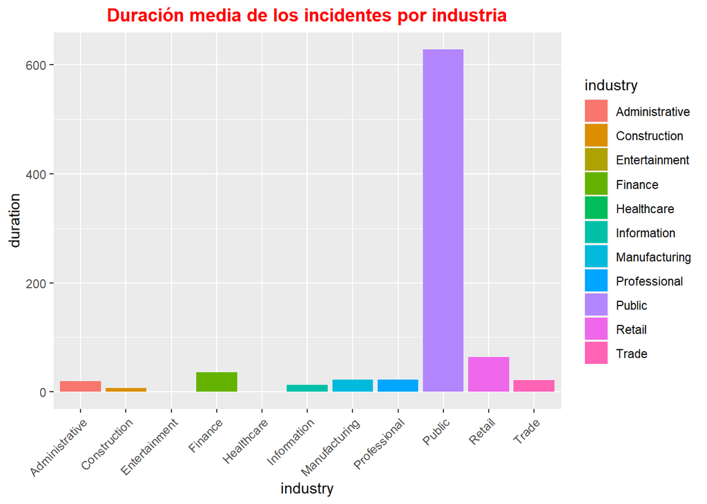

```r
ggplot(data=phishing_summary, aes(x=industry, y=duration, fill=industry)) + geom_bar(stat="identity") + theme(axis.text.x=element_text(angle=45,hjust=1,vjust=1)) + ggtitle ("Duración media de los incidentes por industria") + theme (plot.title = element_text(hjust=0.5, face="bold", color="red", lineheight=1.5))
```

De estos gráficos llama la atención que sólo se ha producido un incidente relacionado con *phishing* en el sector público pero éste ha sido exageradamente largo (en comparación con la media del resto de sectores). No obstante, tratándose de un sólo incidente y que, en estadística, cualquier muestra inferior a una población de 200 elementos no se debe considerar significativa, quizá pueda considerarase un *outlier*.

## ¿Quien estaba detras de los ataques?

La tabla **groups** contiene, para cada uno de los incidentes obtenidos, las técnicas usadas y los grupos que es sabido que usan esas técnicas (según *Mitre Att&ck*).

Para simplificar la gestión de los datos, empezaremos por seleccionar las columans que pueden resultar útiles y renombraremos algunas columnas a nombres más simples.

```r
groups <- select(groups, from, first_event_ts, org, duration, tactic, technique, industry, url.y, description.y, name)
groups <- rename(groups, url = url.y)
groups <- rename(groups, description = description.y)
colnames(groups)
```

```
##  [1] "from"           "first_event_ts" "org"            "duration"
##  [5] "tactic"         "technique"      "industry"       "url"
##  [9] "description"    "name"
```

Si contabilizamos cuántos grupos son sospechosos de haber perpetrado estos ataques (según la información obtenida gracias a *Mitre Att&ck*) encontramos **91**.

```r
distinct(groups, name)
```

```
##                  name
## 1               APT32
## 2   Threat Group-1314
## 3             Silence
## 4            menuPass
## 5          Deep Panda
## 6              OilRig
## 7          MuddyWater
## 8           Leviathan
## 9               APT29
## 10  Threat Group-3390
## 11               FIN8
## 12     Stealth Falcon
## 13      Lazarus Group
## 14            GALLIUM
```

[output cut: 77 more lines]

```r
# Load packages
library(shiny)
```

```r
library(shinythemes)
library(dplyr)
library(readr)

# Load data
#trend_data <- read_csv("data/trend_data.csv")
#trend_description <- read_csv("data/trend_description.csv")

# Define UI
ui <- fluidPage(theme = shinytheme("lumen"),
  titlePanel("Google Trend Index"),
  sidebarLayout(
    sidebarPanel(

      # Select type of trend to plot
      selectInput(inputId = "type", label = strong("Trend index"),
                  choices = unique(groups$industry),
                  selected = "Travel"),

      # Select date range to be plotted
      dateRangeInput("date", strong("Date range"), start = "2007-01-01", end = "2017-07-31",
                     min = "2007-01-01", max = "2017-07-31"),

      # Select whether to overlay smooth trend line
      checkboxInput(inputId = "smoother", label = strong("Overlay smooth trend line"), value = FALSE),

      # Display only if the smoother is checked
      conditionalPanel(condition = "input.smoother == true",
                       sliderInput(inputId = "f", label = "Smoother span:",
                                   min = 0.01, max = 1, value = 0.67, step = 0.01,
                                   animate = animationOptions(interval = 100)),
                       HTML("Higher values give more smoothness.")
      )
    ),

    # Output: Description, lineplot, and reference
    mainPanel(
      plotOutput(outputId = "lineplot", height = "300px"),
      textOutput(outputId = "desc"),
      tags$a(href = "https://www.google.com/finance/domestic_trends", "Source: Google Domestic Trends", target = "_blank")
    )
  )
)

# Define server function
server <- function(input, output) {

  # Subset data
  selected_trends <- reactive({
    req(input$date)
    validate(need(!is.na(input$date[1]) & !is.na(input$date[2]), "Error: Please provide both a start and an end date."))
    validate(need(input$date[1] < input$date[2], "Error: Start date should be earlier than end date."))
    groups %>%
      filter(
        type == input$type,
        date > as.POSIXct(input$date[1]) & date < as.POSIXct(input$date[2]
        ))
  })


  # Create scatterplot object the plotOutput function is expecting
  output$lineplot <- renderPlot({
    color = "#434343"
    par(mar = c(4, 4, 1, 1))
    plot(x = selected_trends()$date, y = selected_trends()$close, type = "l",
         xlab = "Date", ylab = "Trend index", col = color, fg = color, col.lab = color, col.axis = color)
    # Display only if smoother is checked
    if(input$smoother){
      smooth_curve <- lowess(x = as.numeric(selected_trends()$date), y = selected_trends()$close, f = input$f)
      lines(smooth_curve, col = "#E6553A", lwd = 3)
    }
  })

  # Pull in description of trend
  output$desc <- renderText({
    trend_text <- filter(trend_description, type == input$type) %>% pull(text)
    paste(trend_text, "The index is set to 1.0 on January 1, 2004 and is calculated only for US search traffic.")
  })
}

# Create Shiny object
shinyApp(ui = ui, server = server)
```

Shiny applications not supported in static R Markdown documents

## ¿Cómo realizaron los ataques?

## ¿Cómo podemos protegernos?

## ¿Qué podemos hacer para prevenir futuros ataques?

## ¿Sería posible predecir ataques?